# FeatureEngineering

## Feature Engineering

**Loading Data:**

```python
import pandas as pd
import numpy as np

df = pd.read_excel('all_health_data.xlsx', index_col=0)
df.info()
```

```
<class 'pandas.core.frame.DataFrame'>
DatetimeIndex: 1017 entries, 2018-05-22 to 2021-03-09
Data columns (total 27 columns):
 #   Column                               Non-Null Count  Dtype
---  ------                               --------------  -----
 0   ActiveEnergyBurned (Cal)             87 non-null     float64
 1   AppleExerciseTime (min)              87 non-null     float64
 2   AppleStandTime (min)                 87 non-null     float64
 3   BasalEnergyBurned (Cal)              87 non-null     float64
 4   BodyFatPercentage (%)                116 non-null    float64
 5   BodyMass (lb)                        146 non-null    float64
 6   BodyMassIndex (count)                121 non-null    float64
 7   DistanceWalkingRunning (mi)          1012 non-null   float64
 8   FlightsClimbed (count)               1015 non-null   float64
 9   HeartRate (count/min)                87 non-null     float64
```

[output cut: 19 more lines]

```python
df.head()
```

|  | ActiveEnergyBurned (Cal) | AppleExerciseTime (min) | AppleStandTime (min) | BasalEnergyBurned (Cal) | BodyFatPercentage (%) | BodyMass (lb) | BodyMassIndex (count) | DistanceWalkingRunning (mi) | FlightsClimbed (count) | HeartRate (count/min) | ... | calories | carbs | fat | protein | sodium | sugar | numWorkouts | duration | totalDistance | totalEnergyBurned |
| --- | --- | --- | --- | --- | --- | --- | --- | --- | --- | --- | --- | --- | --- | --- | --- | --- | --- | --- | --- | --- | --- |
| 2018-05-22 | NaN | NaN | NaN | NaN | NaN | NaN | NaN | 1.362275 | 3.0 | NaN | ... | NaN | NaN | NaN | NaN | NaN | NaN | NaN | NaN | NaN | NaN |
| 2018-05-23 | NaN | NaN | NaN | NaN | NaN | NaN | NaN | 2.086987 | 11.0 | NaN | ... | NaN | NaN | NaN | NaN | NaN | NaN | NaN | NaN | NaN | NaN |
| 2018-05-24 | NaN | NaN | NaN | NaN | NaN | NaN | NaN | 3.361457 | 10.0 | NaN | ... | NaN | NaN | NaN | NaN | NaN | NaN | NaN | NaN | NaN | NaN |
| 2018-05-25 | NaN | NaN | NaN | NaN | NaN | NaN | NaN | 5.220421 | 13.0 | NaN | ... | NaN | NaN | NaN | NaN | NaN | NaN | NaN | NaN | NaN | NaN |
| 2018-05-26 | NaN | NaN | NaN | NaN | NaN | NaN | NaN | 0.943769 | 3.0 | NaN | ... | NaN | NaN | NaN | NaN | NaN | NaN | NaN | NaN | NaN | NaN |

5 rows × 27 columns

**TDEE**

We will compute my TDEE each day and drop the active energy and basal energy columns.

```python
df['TDEE (Cal)'] = df['ActiveEnergyBurned (Cal)'] + df['BasalEnergyBurned (Cal)']
df = df.drop(['ActiveEnergyBurned (Cal)', 'BasalEnergyBurned (Cal)'], axis=1)
df['TDEE (Cal)'].sort_values()
```

```
2020-12-13     571.687
2021-03-09    2004.231
2020-12-18    2381.644
2020-12-16    2611.327
2020-12-25    2649.163
                ...
2020-12-08         NaN
2020-12-09         NaN
2020-12-10         NaN
2020-12-11         NaN
2020-12-12         NaN
Name: TDEE (Cal), Length: 1017, dtype: float64
```

There seems to be a column reporting the total energy burned, which is what we are computing above. Let's look at the quality of this feature and see if it's consistent with our computations.

```python
df[['TDEE (Cal)', 'totalEnergyBurned']].tail(20)
```

|  | TDEE (Cal) | totalEnergyBurned |
| --- | --- | --- |
| 2021-02-18 | 3423.075 | 1087.032309 |
| 2021-02-19 | 3687.268 | 1107.460885 |
| 2021-02-20 | 3851.241 | 1323.668528 |
| 2021-02-21 | 3670.462 | 1226.151193 |
| 2021-02-22 | 3436.913 | 1092.378500 |
| 2021-02-23 | 3521.142 | 1151.699420 |
| 2021-02-24 | 3749.463 | 1290.555522 |
| 2021-02-25 | 3478.698 | 1131.456616 |
| 2021-02-26 | 3689.185 | 1279.577241 |
| 2021-02-27 | 3998.474 | 1284.630359 |
| 2021-02-28 | 3686.054 | 1318.051376 |
| 2021-03-01 | 3568.341 | 1178.476140 |
| 2021-03-02 | 3526.218 | 1111.394121 |
| 2021-03-03 | 3539.942 | 1380.405628 |
| 2021-03-04 | 3467.951 | 1032.987063 |
| 2021-03-05 | 3815.797 | 1212.907723 |
| 2021-03-06 | 3429.201 | 524.699294 |
| 2021-03-07 | 4015.178 | 1616.530609 |
| 2021-03-08 | 3384.140 | 1167.976794 |
| 2021-03-09 | 2004.231 | 812.165946 |

"totalEnergyBurned" is definitely low quality, as I know that I burned around 3,500 calories yesterday (03/08/2021). Thus, we will drop this attribute.

```python
df = df.drop('totalEnergyBurned', axis=1)
df.info()
```

```
<class 'pandas.core.frame.DataFrame'>
DatetimeIndex: 1017 entries, 2018-05-22 to 2021-03-09
Data columns (total 25 columns):
 #   Column                               Non-Null Count  Dtype
---  ------                               --------------  -----
 0   AppleExerciseTime (min)              87 non-null     float64
 1   AppleStandTime (min)                 87 non-null     float64
 2   BodyFatPercentage (%)                116 non-null    float64
 3   BodyMass (lb)                        146 non-null    float64
 4   BodyMassIndex (count)                121 non-null    float64
 5   DistanceWalkingRunning (mi)          1012 non-null   float64
 6   FlightsClimbed (count)               1015 non-null   float64
 7   HeartRate (count/min)                87 non-null     float64
 8   HeartRateVariabilitySDNN (ms)        81 non-null     float64
 9   LeanBodyMass (lb)                    116 non-null    float64
```

[output cut: 17 more lines]

Since I recently got the Apple Watch in December 2020, I won't be able to compute TDEE information for dates before then. Thus, we will use an [online TDEE calculator](https://tdeecalculator.net/) to fill in the missing values.

```python
df['TDEE (Cal)'].first_valid_index()
```

```
Timestamp('2020-12-13 00:00:00')
```

Assume that in during 2018-2019 my activity levels were moderate. From the first day of data collection to 5/25/20, my TDEE is reported as 2,525 assuming my weight was 153 lbs. From 5/25/20 to 10/05/20, assuming my weight was around 145 lbs, my TDEE is 2,467. From 10/05/20 to 12/13/20, assuming my weight was around 147 lbs, my TDEE is 2,775.

```python
df['TDEE (Cal)'].loc[:'2020-05-25'] = df['TDEE (Cal)'].loc[:'2020-05-25'].fillna(2525)
df['TDEE (Cal)'].loc['2020-05-26':'2020-10-05'] = df['TDEE (Cal)'].loc['2020-05-26':'2020-10-05'].fillna(2467)
df['TDEE (Cal)'].loc['2020-10-06':'2020-12-13'] = df['TDEE (Cal)'].loc['2020-10-06':'2020-12-13'].fillna(2775)
```

**Total Workout Duration**

"AppleExerciseTime (min)" and duration both measure the duration of physical activity during the day. Let's look at how these compare.

```python
import seaborn as sns
import matplotlib.pyplot as plt
```

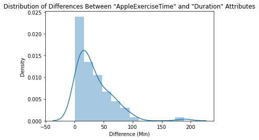

```python
sns.distplot(df[['AppleExerciseTime (min)', 'duration']].diff(axis=1)['duration'].dropna().abs().sort_values())
plt.xlabel('Difference (Min)')
plt.title('Distribution of Differences Between "AppleExerciseTime" and "Duration" Attributes')
```

It seems like there are some days where the difference between the two is quite large. However, they are quite similar the majority of days. Thus, we will average the two attributes.

```python
df['TotalExerciseDuration (min)'] = df[['AppleExerciseTime (min)', 'duration']].mean(axis=1)
df = df.drop(['AppleExerciseTime (min)', 'duration'], axis=1)
df.info()
```

```
<class 'pandas.core.frame.DataFrame'>
DatetimeIndex: 1017 entries, 2018-05-22 to 2021-03-09
Data columns (total 24 columns):
 #   Column                               Non-Null Count  Dtype
---  ------                               --------------  -----
 0   AppleStandTime (min)                 87 non-null     float64
 1   BodyFatPercentage (%)                116 non-null    float64
 2   BodyMass (lb)                        146 non-null    float64
 3   BodyMassIndex (count)                121 non-null    float64
 4   DistanceWalkingRunning (mi)          1012 non-null   float64
 5   FlightsClimbed (count)               1015 non-null   float64
 6   HeartRate (count/min)                87 non-null     float64
 7   HeartRateVariabilitySDNN (ms)        81 non-null     float64
 8   LeanBodyMass (lb)                    116 non-null    float64
 9   OxygenSaturation (%)                 87 non-null     float64
```

[output cut: 16 more lines]

**Distance Traveled**

"DistanceWalkingRunning (mi)" and "totalDistance" both measure the total distance traveled during the day. As done for exercise durations, let's compare these two attributes.

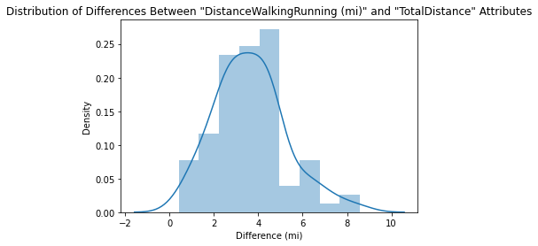

```python
sns.distplot(df[['DistanceWalkingRunning (mi)', 'totalDistance']].diff(axis=1)['totalDistance'].dropna().abs().sort_values())
plt.xlabel('Difference (mi)')
plt.title('Distribution of Differences Between "DistanceWalkingRunning (mi)" and "TotalDistance" Attributes')
```

The differences seem normally distributed centered around 4 miles. This is not a good sign, as the difference is quite significant. Let's look more closely at this difference.

```python
dates = df[['DistanceWalkingRunning (mi)', 'totalDistance']].diff(axis=1)['totalDistance'].dropna().sort_values().index
for i in range(8):
    if i % 2 == 0:
        display(df.loc[dates[i]])
    else:
        display(df.loc[dates[-i]])
    print()
```

```
AppleStandTime (min)                     274.000000
BodyFatPercentage (%)                           NaN
BodyMass (lb)                                   NaN
BodyMassIndex (count)                           NaN
DistanceWalkingRunning (mi)                8.583059
FlightsClimbed (count)                    11.000000
HeartRate (count/min)                     77.777354
HeartRateVariabilitySDNN (ms)             64.573733
LeanBodyMass (lb)                               NaN
OxygenSaturation (%)                       0.976429
RestingHeartRate (count/min)                    NaN
StepCount (count)                      18710.500000
WalkingHeartRateAverage (count/min)             NaN
WalkingSpeed (mi/hr)                       2.531077
calories                                2787.000000
carbs                                    351.000000
fat                                       54.000000
protein                                  226.000000
sodium                                  2803.000000
sugar                                    119.000000
numWorkouts                                1.000000
totalDistance                              0.000000
TDEE (Cal)                              2791.792000
TotalExerciseDuration (min)              101.908002
Name: 2020-12-17 00:00:00, dtype: float64
```

```
AppleStandTime (min)                     194.000000
BodyFatPercentage (%)                           NaN
BodyMass (lb)                                   NaN
BodyMassIndex (count)                           NaN
DistanceWalkingRunning (mi)                7.044348
FlightsClimbed (count)                    12.000000
HeartRate (count/min)                     85.746123
HeartRateVariabilitySDNN (ms)             62.480600
LeanBodyMass (lb)                               NaN
OxygenSaturation (%)                       0.967500
RestingHeartRate (count/min)              48.000000
StepCount (count)                      13273.500000
WalkingHeartRateAverage (count/min)       86.500000
WalkingSpeed (mi/hr)                       3.342976
calories                                2720.000000
carbs                                    355.000000
fat                                       58.000000
protein                                  205.000000
sodium                                  2417.000000
sugar                                     82.000000
numWorkouts                                4.000000
totalDistance                             14.788169
TDEE (Cal)                              2649.163000
TotalExerciseDuration (min)              115.049858
Name: 2020-12-25 00:00:00, dtype: float64
```

```
AppleStandTime (min)                     282.000000
BodyFatPercentage (%)                      0.116000
BodyMass (lb)                            156.433333
BodyMassIndex (count)                     21.300000
DistanceWalkingRunning (mi)                8.634019
FlightsClimbed (count)                    17.500000
HeartRate (count/min)                    101.827310
HeartRateVariabilitySDNN (ms)             44.290200
LeanBodyMass (lb)                        138.600000
OxygenSaturation (%)                       0.980000
RestingHeartRate (count/min)              58.000000
StepCount (count)                      16230.500000
WalkingHeartRateAverage (count/min)      104.000000
WalkingSpeed (mi/hr)                       2.799154
calories                                        NaN
carbs                                           NaN
fat                                             NaN
protein                                         NaN
sodium                                          NaN
sugar                                           NaN
numWorkouts                                4.000000
totalDistance                              1.887335
TDEE (Cal)                              3429.201000
TotalExerciseDuration (min)              122.324287
Name: 2021-03-06 00:00:00, dtype: float64
```

```
AppleStandTime (min)                     235.000000
BodyFatPercentage (%)                      0.107000
BodyMass (lb)                            152.600000
BodyMassIndex (count)                     20.700000
DistanceWalkingRunning (mi)                6.095527
FlightsClimbed (count)                    17.000000
HeartRate (count/min)                    100.916716
HeartRateVariabilitySDNN (ms)             31.067900
LeanBodyMass (lb)                        136.400000
OxygenSaturation (%)                       0.984000
RestingHeartRate (count/min)                    NaN
StepCount (count)                      13840.000000
WalkingHeartRateAverage (count/min)             NaN
WalkingSpeed (mi/hr)                       3.075301
calories                                2988.000000
carbs                                    445.000000
fat                                       46.000000
protein                                  227.000000
sodium                                  2720.000000
sugar                                    148.000000
numWorkouts                                7.000000
totalDistance                              6.708734
TDEE (Cal)                              2664.855000
TotalExerciseDuration (min)              164.843441
Name: 2021-02-04 00:00:00, dtype: float64
```

```
AppleStandTime (min)                     198.000000
BodyFatPercentage (%)                           NaN
BodyMass (lb)                            145.692784
BodyMassIndex (count)                           NaN
DistanceWalkingRunning (mi)                6.383423
FlightsClimbed (count)                     9.000000
HeartRate (count/min)                     81.561159
HeartRateVariabilitySDNN (ms)             69.188700
LeanBodyMass (lb)                               NaN
OxygenSaturation (%)                       0.978235
RestingHeartRate (count/min)              48.000000
StepCount (count)                      14194.500000
WalkingHeartRateAverage (count/min)       66.500000
WalkingSpeed (mi/hr)                       2.634322
calories                                2787.000000
carbs                                    351.000000
fat                                       54.000000
protein                                  226.000000
sodium                                  2803.000000
sugar                                    119.000000
numWorkouts                                2.000000
totalDistance                              0.000000
TDEE (Cal)                              2706.000000
TotalExerciseDuration (min)              244.371467
Name: 2020-12-14 00:00:00, dtype: float64
```

```
AppleStandTime (min)                     254.000000
BodyFatPercentage (%)                      0.115000
BodyMass (lb)                            157.000000
BodyMassIndex (count)                     21.250000
DistanceWalkingRunning (mi)                6.976628
FlightsClimbed (count)                    66.500000
HeartRate (count/min)                     85.654429
HeartRateVariabilitySDNN (ms)                   NaN
LeanBodyMass (lb)                        138.900000
OxygenSaturation (%)                       1.000000
RestingHeartRate (count/min)              56.000000
StepCount (count)                      13990.500000
WalkingHeartRateAverage (count/min)             NaN
WalkingSpeed (mi/hr)                       2.821335
calories                                2793.000000
carbs                                    411.000000
fat                                       52.000000
protein                                  189.000000
sodium                                  3019.000000
sugar                                     79.000000
numWorkouts                                4.000000
totalDistance                              5.942809
TDEE (Cal)                              3261.145000
TotalExerciseDuration (min)              164.838474
Name: 2021-01-15 00:00:00, dtype: float64
```

```
AppleStandTime (min)                     292.000000
BodyFatPercentage (%)                           NaN
BodyMass (lb)                                   NaN
BodyMassIndex (count)                           NaN
DistanceWalkingRunning (mi)                7.124621
FlightsClimbed (count)                     3.500000
HeartRate (count/min)                     88.742406
HeartRateVariabilitySDNN (ms)             28.144700
LeanBodyMass (lb)                               NaN
OxygenSaturation (%)                       0.990000
RestingHeartRate (count/min)              47.000000
StepCount (count)                      13609.000000
WalkingHeartRateAverage (count/min)       77.500000
WalkingSpeed (mi/hr)                       2.805270
calories                                 945.000000
carbs                                     99.000000
fat                                       17.000000
protein                                  100.000000
sodium                                   964.000000
sugar                                     15.000000
numWorkouts                                2.000000
totalDistance                              1.074695
TDEE (Cal)                              2955.740000
TotalExerciseDuration (min)              141.903484
Name: 2020-12-19 00:00:00, dtype: float64
```

```
AppleStandTime (min)                     266.000000
BodyFatPercentage (%)                      0.114000
BodyMass (lb)                            155.800000
BodyMassIndex (count)                     21.100000
DistanceWalkingRunning (mi)               10.927049
FlightsClimbed (count)                    15.000000
HeartRate (count/min)                     84.225272
HeartRateVariabilitySDNN (ms)             72.464675
LeanBodyMass (lb)                        138.200000
OxygenSaturation (%)                       0.976667
RestingHeartRate (count/min)              56.000000
StepCount (count)                      20442.000000
WalkingHeartRateAverage (count/min)       82.000000
WalkingSpeed (mi/hr)                       3.112177
calories                                        NaN
carbs                                           NaN
fat                                             NaN
protein                                         NaN
sodium                                          NaN
sugar                                           NaN
numWorkouts                                8.000000
totalDistance                              9.699960
TDEE (Cal)                              3539.942000
TotalExerciseDuration (min)              295.451410
Name: 2021-03-03 00:00:00, dtype: float64
```

It seems like "totalDistance" measures the total distance traveled during all workouts that I tracked on my Apple Watch. In other words, if I don't track an outdoor walk but still walk 5 miles, "totalDistance" will be 0, while "DistanceWalkingRunning (mi)" will be 5.

To correct the ambiguity, we will take the max of the two attributes.

```python
df['TotalDistanceTraveled (mi)'] = df[['DistanceWalkingRunning (mi)', 'totalDistance']].max(axis=1)
df = df.drop(['DistanceWalkingRunning (mi)', 'totalDistance'], axis=1)
df.info()
```

```
<class 'pandas.core.frame.DataFrame'>
DatetimeIndex: 1017 entries, 2018-05-22 to 2021-03-09
Data columns (total 23 columns):
 #   Column                               Non-Null Count  Dtype
---  ------                               --------------  -----
 0   AppleStandTime (min)                 87 non-null     float64
 1   BodyFatPercentage (%)                116 non-null    float64
 2   BodyMass (lb)                        146 non-null    float64
 3   BodyMassIndex (count)                121 non-null    float64
 4   FlightsClimbed (count)               1015 non-null   float64
 5   HeartRate (count/min)                87 non-null     float64
 6   HeartRateVariabilitySDNN (ms)        81 non-null     float64
 7   LeanBodyMass (lb)                    116 non-null    float64
 8   OxygenSaturation (%)                 87 non-null     float64
 9   RestingHeartRate (count/min)         72 non-null     float64
 10  StepCount (count)                    1012 non-null   float64
 11  WalkingHeartRateAverage (count/min)  68 non-null     float64
 12  WalkingSpeed (mi/hr)                 170 non-null    float64
 13  calories                             309 non-null    float64
 14  carbs                                309 non-null    float64
 15  fat                                  309 non-null    float64
 16  protein                              309 non-null    float64
 17  sodium                               309 non-null    float64
 18  sugar                                309 non-null    float64
 19  numWorkouts                          85 non-null     float64
 20  TDEE (Cal)                           1017 non-null   float64
 21  TotalExerciseDuration (min)          87 non-null     float64
 22  TotalDistanceTraveled (mi)           1012 non-null   float64
dtypes: float64(23)
memory usage: 223.0 KB
```

**Weight**

BodyMass consists of LeanBodyMass and BodyFat. We will disregard LeanBodyMass, as this is not a measurement that I typically care about or even measure. It happens so that my weighing scale measures LeanBodyMass, but due to most scales not providing this measurement, it can be eliminated from this model.

```python
df = df.rename(columns={'BodyMass (lb)': 'Weight (lbs)'}).drop('LeanBodyMass (lb)', axis=1)
df.info()
```

```
<class 'pandas.core.frame.DataFrame'>
DatetimeIndex: 1017 entries, 2018-05-22 to 2021-03-09
Data columns (total 22 columns):
 #   Column                               Non-Null Count  Dtype
---  ------                               --------------  -----
 0   AppleStandTime (min)                 87 non-null     float64
 1   BodyFatPercentage (%)                116 non-null    float64
 2   Weight (lbs)                         146 non-null    float64
 3   BodyMassIndex (count)                121 non-null    float64
 4   FlightsClimbed (count)               1015 non-null   float64
 5   HeartRate (count/min)                87 non-null     float64
 6   HeartRateVariabilitySDNN (ms)        81 non-null     float64
 7   OxygenSaturation (%)                 87 non-null     float64
 8   RestingHeartRate (count/min)         72 non-null     float64
 9   StepCount (count)                    1012 non-null   float64
 10  WalkingHeartRateAverage (count/min)  68 non-null     float64
 11  WalkingSpeed (mi/hr)                 170 non-null    float64
 12  calories                             309 non-null    float64
 13  carbs                                309 non-null    float64
 14  fat                                  309 non-null    float64
 15  protein                              309 non-null    float64
 16  sodium                               309 non-null    float64
 17  sugar                                309 non-null    float64
 18  numWorkouts                          85 non-null     float64
 19  TDEE (Cal)                           1017 non-null   float64
 20  TotalExerciseDuration (min)          87 non-null     float64
 21  TotalDistanceTraveled (mi)           1012 non-null   float64
dtypes: float64(22)
memory usage: 215.0 KB
```

**RPE**

RPE, the rate of perceived exertion, is a numeric estimate of intensity during workouts. It ranges from 6-20, where 6 is the lowest intensity and 20 is the highest. RPE is known to be correlated with heart rate; more specifically, $RPE=heart\_rate/10$.

```python
rpe = ((df['HeartRate (count/min)'] / 10) + np.random.normal(0, 2, df['HeartRate (count/min)'].shape)).round()
rpe
```

```
2018-05-22     NaN
2018-05-23     NaN
2018-05-24     NaN
2018-05-25     NaN
2018-05-26     NaN
              ...
2021-03-05    12.0
2021-03-06     6.0
2021-03-07     5.0
2021-03-08     8.0
2021-03-09    10.0
Name: HeartRate (count/min), Length: 1017, dtype: float64
```

Now, lets visualize TDEE vs RPE.

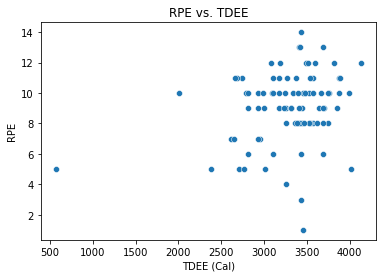

```python
sns.scatterplot(df['TDEE (Cal)'], rpe)
plt.title('RPE vs. TDEE')
plt.ylabel('RPE')
```

Let's build a linear model between the variables.

```python
from sklearn.linear_model import LinearRegression
from math import isnan
```

```python
mod = LinearRegression().fit(pd.concat([rpe, df['TDEE (Cal)']], axis=1).dropna().iloc[:,1].values.reshape(-1, 1), pd.concat([rpe, df['TDEE (Cal)']], axis=1).dropna().iloc[:,0].values)
```

```python
df['RPE'] = rpe
df['RPE'] = df.apply(lambda x: mod.predict([[x['TDEE (Cal)']]])[0] if isnan(x['RPE']) else x['RPE'], axis=1)
df.info()
```

```
<class 'pandas.core.frame.DataFrame'>
DatetimeIndex: 1017 entries, 2018-05-22 to 2021-03-09
Data columns (total 23 columns):
 #   Column                               Non-Null Count  Dtype
---  ------                               --------------  -----
 0   AppleStandTime (min)                 87 non-null     float64
 1   BodyFatPercentage (%)                116 non-null    float64
 2   Weight (lbs)                         146 non-null    float64
 3   BodyMassIndex (count)                121 non-null    float64
 4   FlightsClimbed (count)               1015 non-null   float64
 5   HeartRate (count/min)                87 non-null     float64
 6   HeartRateVariabilitySDNN (ms)        81 non-null     float64
 7   OxygenSaturation (%)                 87 non-null     float64
 8   RestingHeartRate (count/min)         72 non-null     float64
 9   StepCount (count)                    1012 non-null   float64
 10  WalkingHeartRateAverage (count/min)  68 non-null     float64
 11  WalkingSpeed (mi/hr)                 170 non-null    float64
 12  calories                             309 non-null    float64
 13  carbs                                309 non-null    float64
 14  fat                                  309 non-null    float64
 15  protein                              309 non-null    float64
 16  sodium                               309 non-null    float64
 17  sugar                                309 non-null    float64
 18  numWorkouts                          85 non-null     float64
 19  TDEE (Cal)                           1017 non-null   float64
 20  TotalExerciseDuration (min)          87 non-null     float64
 21  TotalDistanceTraveled (mi)           1012 non-null   float64
 22  RPE                                  1017 non-null   float64
dtypes: float64(23)
memory usage: 223.0 KB
```

**Missing Values**

For many attributes, I only started collected data in late 2020. Thus, we will impute using KNN imputation.

```python
from sklearn.impute import KNNImputer
```

```python
imputer = KNNImputer(n_neighbors=50, weights='distance')
new_vals = imputer.fit_transform(df)
imputed_df = pd.DataFrame(new_vals, columns=df.columns, index=df.index)
imputed_df.info()
```

```
<class 'pandas.core.frame.DataFrame'>
DatetimeIndex: 1017 entries, 2018-05-22 to 2021-03-09
Data columns (total 23 columns):
 #   Column                               Non-Null Count  Dtype
---  ------                               --------------  -----
 0   AppleStandTime (min)                 1017 non-null   float64
 1   BodyFatPercentage (%)                1017 non-null   float64
 2   Weight (lbs)                         1017 non-null   float64
 3   BodyMassIndex (count)                1017 non-null   float64
 4   FlightsClimbed (count)               1017 non-null   float64
 5   HeartRate (count/min)                1017 non-null   float64
 6   HeartRateVariabilitySDNN (ms)        1017 non-null   float64
 7   OxygenSaturation (%)                 1017 non-null   float64
 8   RestingHeartRate (count/min)         1017 non-null   float64
 9   StepCount (count)                    1017 non-null   float64
 10  WalkingHeartRateAverage (count/min)  1017 non-null   float64
 11  WalkingSpeed (mi/hr)                 1017 non-null   float64
 12  calories                             1017 non-null   float64
 13  carbs                                1017 non-null   float64
 14  fat                                  1017 non-null   float64
 15  protein                              1017 non-null   float64
 16  sodium                               1017 non-null   float64
 17  sugar                                1017 non-null   float64
 18  numWorkouts                          1017 non-null   float64
 19  TDEE (Cal)                           1017 non-null   float64
 20  TotalExerciseDuration (min)          1017 non-null   float64
 21  TotalDistanceTraveled (mi)           1017 non-null   float64
 22  RPE                                  1017 non-null   float64
dtypes: float64(23)
memory usage: 223.0 KB
```

```python
imputed_df.head()
```

|  | AppleStandTime (min) | BodyFatPercentage (%) | Weight (lbs) | BodyMassIndex (count) | FlightsClimbed (count) | HeartRate (count/min) | HeartRateVariabilitySDNN (ms) | OxygenSaturation (%) | RestingHeartRate (count/min) | StepCount (count) | ... | carbs | fat | protein | sodium | sugar | numWorkouts | TDEE (Cal) | TotalExerciseDuration (min) | TotalDistanceTraveled (mi) | RPE |
| --- | --- | --- | --- | --- | --- | --- | --- | --- | --- | --- | --- | --- | --- | --- | --- | --- | --- | --- | --- | --- | --- |
| 2018-05-22 | 235.986575 | 0.090740 | 145.679205 | 19.653897 | 3.0 | 88.485670 | 60.193376 | 0.975648 | 52.409019 | 3502.0 | ... | 205.347481 | 63.706432 | 164.572747 | 1986.368927 | 65.467094 | 3.622983 | 2525.0 | 158.334372 | 1.362275 | 8.12214 |
| 2018-05-23 | 235.059561 | 0.090348 | 145.341448 | 19.632809 | 11.0 | 87.586683 | 60.610216 | 0.975599 | 52.369399 | 5134.0 | ... | 233.484490 | 64.167978 | 179.103937 | 2078.406016 | 66.568902 | 3.599515 | 2525.0 | 153.456669 | 2.086987 | 8.12214 |
| 2018-05-24 | 229.965618 | 0.092806 | 146.838727 | 19.828214 | 10.0 | 87.172554 | 62.929076 | 0.975539 | 52.140971 | 8326.0 | ... | 326.605775 | 90.338254 | 207.073636 | 3244.304724 | 101.161070 | 3.507996 | 2525.0 | 145.785345 | 3.361457 | 8.12214 |
| 2018-05-25 | 229.284116 | 0.091129 | 145.797181 | 19.676036 | 13.0 | 89.588053 | 61.780141 | 0.975677 | 51.843644 | 12920.0 | ... | 300.462475 | 59.515022 | 197.779293 | 2766.927515 | 88.934790 | 3.434425 | 2525.0 | 158.323106 | 5.220421 | 8.12214 |
| 2018-05-26 | 236.493879 | 0.090775 | 145.839115 | 19.655141 | 3.0 | 88.789922 | 59.974716 | 0.975644 | 52.429769 | 2251.0 | ... | 201.360567 | 56.310828 | 156.189866 | 2073.707127 | 64.942418 | 3.636138 | 2525.0 | 160.277752 | 0.943769 | 8.12214 |

5 rows × 23 columns

Imputing creates float values for some attributes that should have integer types. Let's round these attributes to convert them back to integers.

```python
int_cols = ['AppleStandTime (min)', 'BodyMassIndex (count)', 'FlightsClimbed (count)', 'StepCount (count)', 'calories', 'carbs', 'fat', 'protein', 'sodium', 'sugar', 'numWorkouts', 'TDEE (Cal)', 'RPE']
for col in int_cols:
    imputed_df[col] = imputed_df[col].round()
```

Before May 15, 2020, my data was limited, so we will randomly introduce missing values for these dates. I started getting serious about tracking when I came home after the Spring semester.

```python
for att in imputed_df.columns:
    if att in ['Weight (lbs)', 'calories', 'carbs', 'fat', 'protein', 'sodium', 'sugar', 'numWorkouts']:
        frac = 0.5
    else:
        frac = (np.random.randint(5) + 1) / 10
    imputed_df.loc[imputed_df.loc[:'2020-05-15'].sample(frac=frac).index, att] = pd.np.nan
```

```python
imputed_df.info()
```

[output not shown]

Lastly, lets rename the columns for formatting purposes.

```python
imputed_df = imputed_df.rename(columns={'HeartRate (count/min)':'HeartRate (bpm)', 'RestingHeartRate (count/min)':'RestingHeartRate (bpm)', 'HeartRateVariabilitySDNN (ms)':'HeartRateVariability (ms)', 'WalkingHeartRateAverage (count/min)':'WalkingHeartRateAverage (bpm)', 'WalkingSpeed (mi/hr)':'WalkingSpeed (mph)', 'calories':'Calories', 'carbs':'Carbs (g)', 'fat':'Fat (g)', 'protein':'Protein (g)', 'sodium':'Sodium (mg)', 'sugar':'Sugar (g)', 'numWorkouts':'NumWorkouts', 'TDEE (Cal)':'TDEE (cal)'})
imputed_df.info()
```

[output not shown]

**Walking Heart Rate**

As studied in the ETL process, "HeartRate (bpm)" includes the measurements from "WalkingHeartRateAverage (bpm)", so we can drop this attribute as well.

```python
imputed_df = imputed_df.drop('WalkingHeartRateAverage (bpm)', axis=1)
```

Finally, let's export the final data to a spreadsheet.

```python
imputed_df.to_excel('final_health_data.xlsx')
```